# Handout- Sampling Distributions

Jacob Thoma

## On your own

So far, we have only focused on estimating the mean living area in homes in Ames. Now you’ll try to estimate the mean home price.

1. Take a random sample of size 50 from `price`. Using this sample, what is your best point estimate of the population mean?

```r
download.file("http://www.openintro.org/stat/data/ames.RData", destfile = "ames.RData")
load("ames.RData")

area <- ames$Gr.Liv.Area
price <- ames$SalePrice

samp2 <- sample(price, 50)
mean(samp2)
```

```
## [1] 165295.1
```

2. Since you have access to the population, simulate the sampling distribution for $\bar{x}_{price}$ by taking 5000 samples from the population of size 50 and computing 5000 sample means. Store these means in a vector called `sample_means50`. Plot the data, then describe the shape of this sampling distribution. Based on this sampling distribution, what would you guess the mean home price of the population to be? Finally, calculate and report the population mean.

   Answer:  
   The histogram of the sample means is very symetrical. Based on the histogram alone I’d guess the mean population home proce would be very close to 180k.  
   After calculating the actual population mean I got 180,796.1 which is very close to my estimate based off the samples.

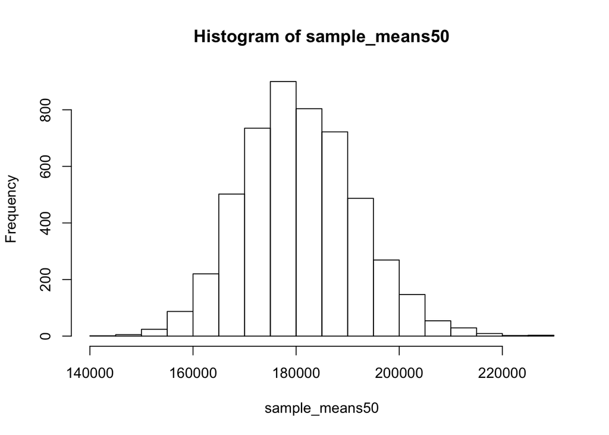

```r
sample_means50 <- rep(NA, 5000)

for(i in 1:5000){
  samp <- sample(price, 50)
  sample_means50[i] <- mean(samp)
}

hist(sample_means50, breaks = 25)
```

```r
mean(price)
```

```
## [1] 180796.1
```

3. Change your sample size from 50 to 150, then compute the sampling distribution using the same method as above, and store these means in a new vector called `sample_means150`. Describe the shape of this sampling distribution, and compare it to the sampling distribution for a sample size of 50. Based on this sampling distribution, what would you guess to be the mean sale price of homes in Ames?

   Answer:  
   Again the sampling distribution is fairly symetrical but the peak appears to have moved higher than it was when we only had 50 samples. Based on this data distribution I would predict the mean to be around 181k (which is closer to the known mean)

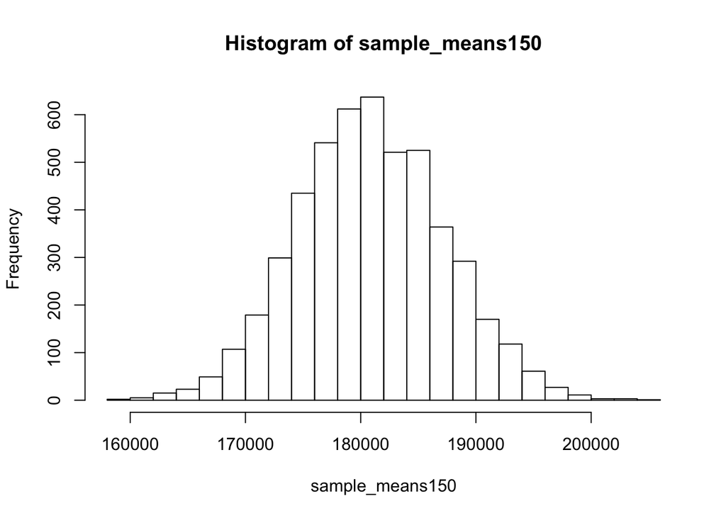

```r
sample_means150 <- rep(NA, 5000)

for(i in 1:5000){
  samp <- sample(price, 150)
  sample_means150[i] <- mean(samp)
}

hist(sample_means150, breaks = 25)
```

4. Of the sampling distributions from 2 and 3, which has a smaller spread? If we’re concerned with making estimates that are more often close to the true value, would we prefer a distribution with a large or small spread?

   Answer:  
   The spread is smaller on the distribution where our sample was 150 which is preferable when we are trying to hone in on making estimates closse to the true value.

This is a product of OpenIntro that is released under a [Creative Commons Attribution-ShareAlike 3.0 Unported](http://creativecommons.org/licenses/by-sa/3.0). This lab was written for OpenIntro by Andrew Bray and Mine Çetinkaya-Rundel.